# Non-Uniform Mixtures and Grain-Size Dependent Provenance

## Overview

Standard provenance unmixing assumes that each sample is a **uniform mixture** of its sources — that is, the mixing proportions (A) are the same regardless of which analytical technique or grain-size fraction is examined. In practice, this assumption is often violated: different source areas supply sediment predominantly in different grain-size ranges, so the apparent contribution of each source shifts systematically across fractions.

This vignette demonstrates how `geomix` handles this scenario through the concept of **local mixing proportions** (`A_local`). Using the `dummy6` synthetic dataset — where ground truth is fully known — we show that:

1. A joint unmixing fit (`A_global`) recovers a single, fraction-averaged proportion per sample, missing the grain-size-dependent signal.
2. `A_local` re-estimates proportions separately for each fraction by fixing the known end-member signatures (B) and re-solving for A per fraction, recovering the true mixing curves.
3. The divergence between `A_local` and `A_global` is itself a diagnostic: large divergence signals non-uniform mixing; small divergence confirms the global assumption holds.

## The DUMMY6 Dataset

`dummy6` is a fully synthetic benchmark with **known ground truth**, designed to test the detection and reconstruction of grain-size-dependent mixing. It contains:

- **15 samples** (S01–S15), each a mixture of 3 end-members with varying proportions
- **6 grain-size fractions**: Very Coarse Sand (VCS), Coarse Sand (CS), Medium Sand (MS), Fine Sand (FS), Silt, and Clay
- **6 minerals** per fraction: Qtz, Fsp, Mica, Carb, Clay, Lith
- **End-member grain-size preferences**: EM1 concentrates in coarse fractions, EM3 in fine fractions, EM2 intermediate — so the apparent mixing proportions shift predictably across fractions

```r
library(geomix)
library(tidyverse)
library(clue)
library(nnls)
data(dummy6)

fractions <- dummy6$fractions  # VCS, CS, MS, FS, Silt, Clay
minerals  <- dummy6$minerals   # Qtz, Fsp, Mica, Carb, Clay, Lith
```

### End-member grain-size preferences

The key feature of DUMMY6 is that each end-member contributes differently to each fraction. EM1 dominates coarse sand; EM3 dominates clay — creating predictable mixing curves that shift monotonically from coarse to fine.

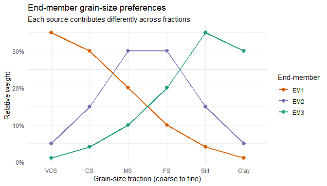

```r
dummy6$EM_grainsize |>
  pivot_longer(-EM, names_to = "fraction", values_to = "weight") |>
  mutate(fraction = factor(fraction, levels = fractions)) |>
  ggplot(aes(x = fraction, y = weight, color = EM, group = EM)) +
  geom_line(linewidth = 1) +
  geom_point(size = 2.5) +
  scale_y_continuous(labels = scales::percent_format()) +
  scale_color_manual(
    values = c("EM1" = "#d95f02", "EM2" = "#7570b3", "EM3" = "#1b9e77")
  ) +
  labs(
    title    = "End-member grain-size preferences",
    subtitle = "Each source contributes differently across fractions",
    x        = "Grain-size fraction (coarse to fine)",
    y        = "Relative weight",
    color    = "End-member"
  ) +
  theme_minimal(base_size = 11)
```

Because of these preferences, the true mixing proportions per fraction (`A_per_fraction`) differ substantially from the bulk total proportions (`A_total`). This grain-size-dependent signal is what `A_local` aims to recover.

## Building the Data Blocks

Each grain-size fraction becomes a separate compositional block. All six fractions are passed jointly to `unmix()`, sharing a single A matrix across them.

```r
blocks <- fractions |>
  set_names() |>
  map(\(frac) {
    build_compositional_block(
      comp_df   = dummy6$observed[[frac]],
      comp_cols = minerals,
      apply_clr = FALSE
    )
  })
common_samples <- Reduce(intersect, lapply(blocks, `[[`, "samples"))

data_list  <- map(blocks, \(b) b$data_mat[common_samples, ])
data_types <- set_names(rep("simplex", length(fractions)), fractions)
```

## Joint Unmixing: A_global

`unmix()` fits a single **global** A matrix — one set of proportions per sample, shared across all fractions. This is the standard unmixing result.

```r
set.seed(123)

fit <- unmix(
  data_list  = data_list,
  data_types = data_types,
  K          = 3,
  weighting  = "inv_f",
  adaptive   = "none",
  verbose    = FALSE
)

# Align A_global to true EM labels via Hungarian algorithm
B_true <- dummy6$EM_mineralogy |>
  select(-EM) |>
  as.matrix()
rownames(B_true) <- dummy6$EM_mineralogy$EM
B_true   <- B_true[, minerals]
em_names <- rownames(B_true)

B_ref <- fit$B_list[[1]][, minerals]
cost  <- outer(
  seq_len(nrow(B_ref)), seq_len(nrow(B_true)),
  Vectorize(\(i, j) mean(abs(B_ref[i, ] - B_true[j, ])))
)
perm             <- as.integer(solve_LSAP(cost))
A_global_aligned <- fit$A[, perm]
colnames(A_global_aligned) <- em_names

cat("A_global dimensions:", dim(A_global_aligned), "\n")
```

```
#> A_global dimensions: 15 3
```

```r
cat("Permutation (Source -> EM):", perm, "\n")
```

```
#> Permutation (Source -> EM): 3 1 2
```

## Computing A_local

The key insight: fix the known end-member signatures (B) and **re-solve for A independently within each fraction**. This allows mixing proportions to vary across fractions while keeping the end-member identities fully consistent.

```r
# Helper: solve A given fixed B, row-by-row with NNLS + simplex normalisation
solve_A_fixed_B <- function(X, B) {
  X  <- as.matrix(X)
  B  <- as.matrix(B)
  N  <- nrow(X)
  K  <- nrow(B)
  Bt <- t(B)
  A_est <- matrix(NA_real_, nrow = N, ncol = K,
                  dimnames = list(rownames(X), rownames(B)))
  for (i in seq_len(N)) {
    a_i <- coef(nnls(Bt, as.numeric(X[i, ])))
    s   <- sum(a_i)
    A_est[i, ] <- if (s > 0) a_i / s else rep(1 / K, K)
  }
  A_est
}

# Compute A_local for every fraction using true B
A_local_by_fraction <- fractions |>
  set_names() |>
  map(\(frac) {
    X <- blocks[[frac]]$data_mat[common_samples, ]
    solve_A_fixed_B(X, B_true)
  })

cat("A_local computed for:", names(A_local_by_fraction), "\n")
```

```
#> A_local computed for: VCS CS MS FS Silt Clay
```

## Mixing Curves: All Samples

The central result: how end-member proportions change across fractions for all 15 samples. Each column is a sample; each row is an end-member. Black = true A per fraction; green = A_local; orange = A_global (flat line).

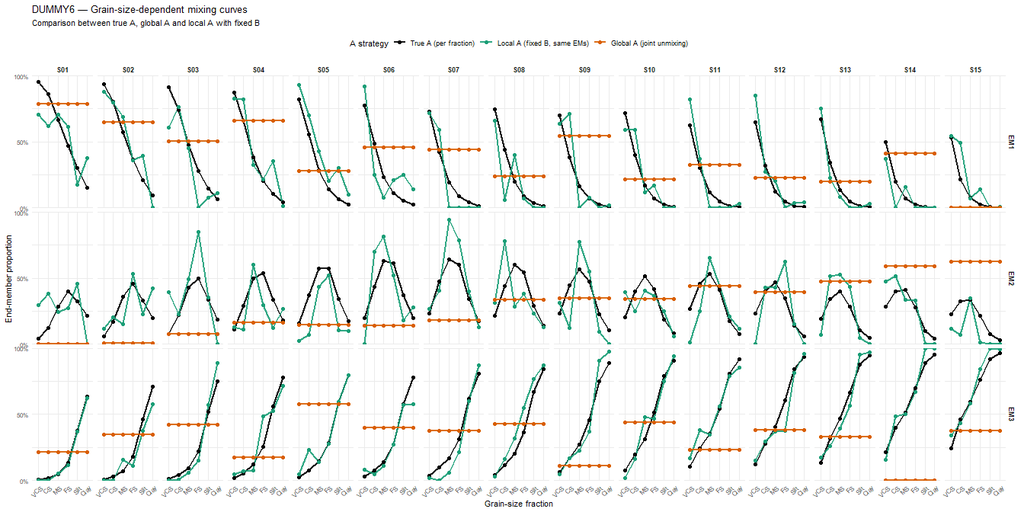

```r
# True A per fraction
df_true <- fractions |>
  map_df(\(frac) {
    dummy6$A_per_fraction |>
      filter(fraction == frac) |>
      pivot_longer(starts_with("EM"), names_to = "EM", values_to = "value") |>
      mutate(type = "True A (per fraction)", fraction = frac)
  })

# A_local per fraction
df_local <- fractions |>
  map_df(\(frac) {
    A_local_by_fraction[[frac]] |>
      as.data.frame() |>
      rownames_to_column("sample") |>
      pivot_longer(-sample, names_to = "EM", values_to = "value") |>
      mutate(type = "Local A (fixed B, same EMs)", fraction = frac)
  })

# A_global replicated as flat line across all fractions
df_global <- A_global_aligned |>
  as.data.frame() |>
  rownames_to_column("sample") |>
  pivot_longer(-sample, names_to = "EM", values_to = "value") |>
  crossing(fraction = fractions) |>
  mutate(type = "Global A (joint unmixing)")

# Combine and set factor levels
df_plot <- bind_rows(df_true, df_local, df_global) |>
  mutate(
    sample   = factor(sample,   levels = paste0("S", sprintf("%02d", 1:15))),
    fraction = factor(fraction, levels = fractions),
    EM       = factor(EM,       levels = em_names),
    type     = factor(type, levels = c(
      "True A (per fraction)",
      "Local A (fixed B, same EMs)",
      "Global A (joint unmixing)"
    ))
  )

ggplot(df_plot, aes(x = fraction, y = value, color = type, group = type)) +
  geom_line(linewidth = 0.9, alpha = 0.9) +
  geom_point(size = 1.6) +
  facet_grid(EM ~ sample) +
  scale_y_continuous(
    labels = scales::percent_format(),
    limits = c(0, 1),
    breaks = c(0, 0.5, 1),
    expand = c(0, 0)
  ) +
  scale_color_manual(
    values = c(
      "True A (per fraction)"       = "black",
      "Local A (fixed B, same EMs)" = "#1b9e77",
      "Global A (joint unmixing)"   = "#d95f02"
    )
  ) +
  labs(
    title    = "DUMMY6 — Grain-size-dependent mixing curves",
    subtitle = "Comparison between true A, global A and local A with fixed B",
    x        = "Grain-size fraction",
    y        = "End-member proportion",
    color    = "A strategy"
  ) +
  theme_minimal(base_size = 8) +
  theme(
    legend.position = "top",
    axis.text.x     = element_text(angle = 45, hjust = 1, size = 6),
    axis.text.y     = element_text(size = 6),
    strip.text.x    = element_text(face = "bold", size = 7),
    strip.text.y    = element_text(face = "bold", size = 7),
    panel.spacing   = unit(0.3, "lines"),
    legend.key.size = unit(0.5, "cm")
  )
```

## Validation: MAE by Fraction

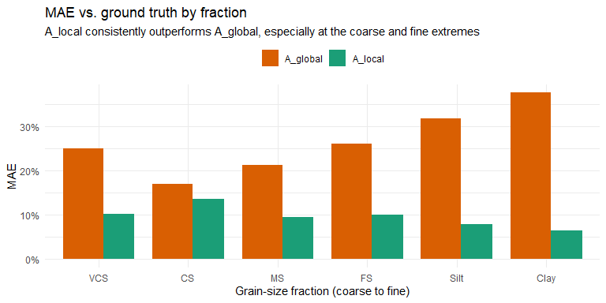

```r
A_true_by_frac <- fractions |>
  set_names() |>
  map(\(frac) {
    dummy6$A_per_fraction |>
      filter(fraction == frac) |>
      select(sample, all_of(em_names)) |>
      column_to_rownames("sample") |>
      as.matrix()
  })

mae_summary <- fractions |>
  map_df(\(frac) {
    A_loc  <- A_local_by_fraction[[frac]][common_samples, ]
    A_glob <- A_global_aligned[common_samples, ]
    A_true <- A_true_by_frac[[frac]][common_samples, ]
    tibble(
      fraction   = frac,
      MAE_local  = mean(abs(A_loc  - A_true)),
      MAE_global = mean(abs(A_glob - A_true))
    )
  }) |>
  mutate(fraction = factor(fraction, levels = fractions))

mae_summary |>
  pivot_longer(starts_with("MAE"), names_to = "strategy", values_to = "MAE") |>
  mutate(strategy = recode(strategy,
    "MAE_local"  = "A_local",
    "MAE_global" = "A_global"
  )) |>
  ggplot(aes(x = fraction, y = MAE, fill = strategy)) +
  geom_col(position = position_dodge(width = 0.7)) +
  scale_fill_manual(values = c("A_local" = "#1b9e77", "A_global" = "#d95f02")) +
  scale_y_continuous(labels = scales::percent_format()) +
  labs(
    title    = "MAE vs. ground truth by fraction",
    subtitle = "A_local consistently outperforms A_global, especially at the coarse and fine extremes",
    x        = "Grain-size fraction (coarse to fine)",
    y        = "MAE",
    fill     = NULL
  ) +
  theme_minimal(base_size = 11) +
  theme(legend.position = "top")
```

```r
print(mae_summary)
```

```
#> # A tibble: 6 × 3
#>   fraction MAE_local MAE_global
#>   <fct>        <dbl>      <dbl>
#> 1 VCS         0.103       0.251
#> 2 CS          0.135       0.170
#> 3 MS          0.0957      0.213
#> 4 FS          0.0995      0.261
#> 5 Silt        0.0790      0.317
#> 6 Clay        0.0654      0.376
```

## Practical Guidance

**When to use `A_local`:**

- When data blocks sample different grain-size fractions (e.g., detrital zircon in fine sand, bulk petrography in medium-coarse sand)
- When you suspect sources differ in their grain-size distributions
- As a **diagnostic** on any multiproxy fit: if `A_local` diverges strongly from `A_global` in a specific block, that block carries fraction-specific information beyond the global signal

**Interpretation of divergence:**

| A_local vs A_global | Interpretation |
| --- | --- |
| Small divergence (all blocks) | Uniform mixing; global assumption holds |
| Large divergence (specific block) | That proxy/fraction sees a different mixture |
| Systematic trend across fractions | Grain-size-dependent provenance (this vignette) |